# tmp

- **Name**: `Packing`
- **Fully Qualified Name**: `org.openprovenance.templates.physical.Packing`
- **IRI**: https://openprovenance.org/templates/org/openprovenance/templates/physical/Packing
- **Purpose**: The template `Packing` describes the evolution of a container as an item is added to it.
- **Context**: the template helps describe common situations in the physical world, involving containers such as boxes or palettes.
- **Design considerations**: The ability to describe the state of the container (before and after inserting an item) and the state of the item (before being packed in the container or after).
- **Automation**: ttfs/config-packing.json

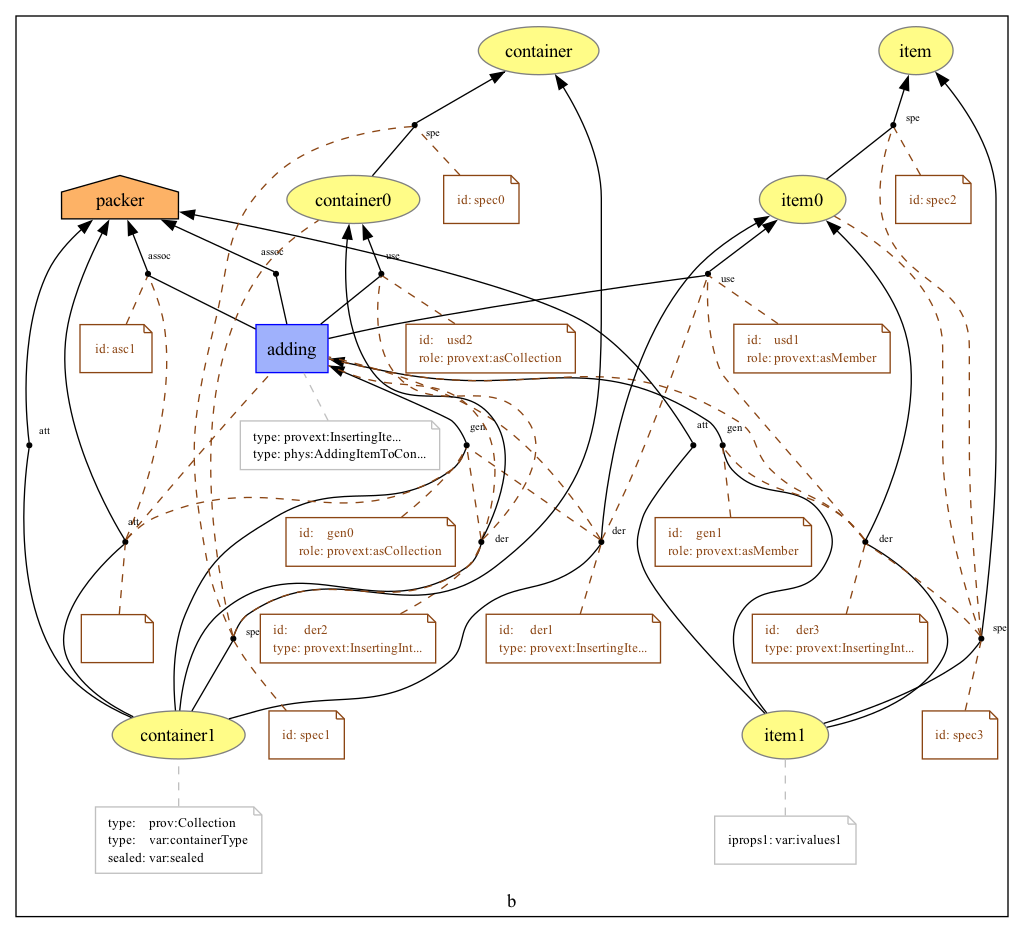

Figure 1: org.openprovenance.templates.physical.Packing

- **Details**:

  This template is a refinement of `org.openprovenance.templates.collections.InsertingIntoCollection` where the collection is a physical container, and the item is physical. At the start, there is a container `container0` and an item `item0`. After this operation, the container `container1` now contains item `item1`.

  The template is the result of merging four instantiated templates.
  - InsertingIntoCollection describes the container and item, before and after the operation
  - Triangle3-AGA to capture the agent (`packer`) responsible for packing the item in the container.
  - Triangle2-Entity-SDS to describe that the container before and the container after are both specialisations of a single container.
  - Triangle2-Entity-SDS to describe that the item before and the item after are both specialisations of a single item.

  As this is a physical operation, the container and item specialisations have a single existence. The creation of `item1` and `container1` invalidates (in the sense of provenance) `item0` and `container0`, though we did not make invalidation edges explicit to avoid overcomplicating the visualisation.